# Trabalho5

Thiago Tavares Lopes

2025-06-24

### 1 Resultados tabela 7.7

Nesta seção são apresentados os resultados da análise dos modelos de regressão logística para os dados da tabela 7.7, que pode ser observada abaixo na tabela abaixo.

| Sexo | ECG | Presente | Ausente | Total | VO |
| --- | --- | --- | --- | --- | --- |
| Feminino | < 0,1 ST | 4 | 11 | 15 | 0.2666667 |
| Feminino | ≥ 0,1 ST | 8 | 10 | 18 | 0.4444444 |
| Masculino | < 0,1 ST | 9 | 9 | 18 | 0.5000000 |
| Masculino | ≥ 0,1 ST | 21 | 6 | 27 | 0.7777778 |

Após o ajuste, temos como modelo final $\log(\frac{\theta(x)}{1-\theta(x)})=-1.1747 + 1.2770 * (SexoMasculino) + 1.0545 * (ECG≥ 0,1 ST)$

| **Variável** | **log(OR)** | **95% CI** | **p-value** |
| --- | --- | --- | --- |
| (Intercept) | -1.2 | -2.2, -0.27 | 0.016 |
| Sexo |  |  |  |
| Feminino | — | — |  |
| Masculino | 1.3 | 0.32, 2.3 | 0.010 |
| ECG |  |  |  |
| < 0,1 ST | — | — |  |
| ≥ 0,1 ST | 1.1 | 0.09, 2.1 | 0.034 |

Abbreviations: CI = Confidence Interval, OR = Odds Ratio

**Interpretação dos Coeficientes Estimados**

- Intercepto (`-1.1747`) O intercepto representa o logit da probabilidade de ocorrência do evento para **mulheres** (`Sexo = Feminino`) com **ECG normal** (categoria de referência). Convertendo o logit em probabilidade:

$$\text{Probabilidade} = \frac{1}{1 + e^{-(-1.1747)}} \approx 0.236$$

Assim, para mulheres com ECG normal, a probabilidade estimada de ocorrência do evento é de aproximadamente **23,6%**.

#### 1.1 Sexo Masculino (`1.2770`)

Indivíduos do sexo **masculino** apresentam um aumento de 1.277 unidades no log-odds da ocorrência do evento em relação às mulheres, mantendo constante a condição do ECG. Convertendo esse valor para *odds ratio*:

$$\text{OR} = e^{1.2770} \approx 3.59$$

Ou seja, **homens têm 3,59 vezes mais chances** de ocorrência do evento do que mulheres, considerando ECG normal.

- ECG ≥ 0,1 ST (`1.0545`) Pessoas com **alteração no ECG (≥ 0,1 ST)** têm um aumento de 1.0545 no log-odds da ocorrência do evento em relação a pessoas com ECG normal, mantendo constante o sexo. O *odds ratio* correspondente é:

$$\text{OR} = e^{1.0545} \approx 2.87$$

Assim, indivíduos com esse tipo de alteração no ECG têm **2,87 vezes mais chances** de ocorrência do evento do que aqueles com ECG normal, considerando o mesmo sexo.

**Significância Estatística** Todos os coeficientes são estatisticamente significativos ao nível de 5%:

- Sexo Masculino: *p* = 0.0103
- ECG ≥ 0,1 ST: *p* = 0.0342
- Intercepto: *p* = 0.0155

**Qualidade do Ajuste**

- **Null Deviance**: 11.98 — representa o desvio do modelo sem preditores.
- **Residual Deviance**: 0.21 — representa o desvio do modelo ajustado.
- A redução drástica sugere um bom ajuste do modelo.
- **AIC**: 19.309 — útil para comparar com outros modelos (quanto menor, melhor).

### 2 Resultados Tabela 7.12

Nesta seção são apresentados os resultados da tabela 7.12. Os dados estão representaos na tabela abaixo

| Diagnostico | Tratamento | Sim | Nao | Total |
| --- | --- | --- | --- | --- |
| Complicada | A | 78 | 28 | 106 |
| Complicada | B | 101 | 11 | 112 |
| Complicada | C | 68 | 46 | 114 |
| Não complicada | A | 40 | 5 | 45 |
| Não complicada | B | 54 | 5 | 59 |
| Não complicada | C | 34 | 6 | 40 |

**Interpretação dos Coeficientes Estimados – Modelo com Interação**

| **Variável** | **log(OR)** | **95% CI** | **p-value** |
| --- | --- | --- | --- |
| (Intercept) | 1.0 | 0.61, 1.5 | <0.001 |
| Diagnostico |  |  |  |
| Complicada | — | — |  |
| Não complicada | 1.1 | 0.10, 2.2 | 0.044 |
| Tratamento |  |  |  |
| A | — | — |  |
| B | 1.2 | 0.46, 2.0 | 0.002 |
| C | -0.63 | -1.2, -0.07 | 0.030 |
| Diagnostico * Tratamento |  |  |  |
| Não complicada * B | -0.89 | -2.4, 0.63 | 0.2 |
| Não complicada * C | 0.29 | -1.1, 1.7 | 0.7 |

Abbreviations: CI = Confidence Interval, OR = Odds Ratio

A fórmula utilizada foi:

```r
glm(cbind(Sucessos, Fracassos) ~ Diagnostico * Tratamento, family = binomial)
```

- Intercepto (`1.0245`) O intercepto representa o logit da probabilidade de ocorrência do evento no grupo de referência, composto por indivíduos com **diagnóstico complicado** e submetidos ao **tratamento A**. A conversão para probabilidade é dada por:

$$P = \frac{1}{1 + e^{-1.0245}} \approx 0.736$$

Logo, a chance de ocorrência do evento nesse grupo é de aproximadamente **73,6%**.

- Diagnóstico não complicada (`1.0549`) Indivíduos com **diagnóstico não complicada**, mantido o tratamento A, apresentam um aumento de 1.0549 na log-odds do evento em comparação com aqueles com diagnóstico complicado. Em termos de *odds ratio*:

$$\text{OR} = e^{1.0549} \approx 2.87$$

Ou seja, há um aumento de aproximadamente **187% nas chances** de ocorrência do evento nesse grupo, com significância estatística (*p* = 0.0437).

- Tratamento B (`1.1927`) Pacientes com diagnóstico complicado tratados com **tratamento B** apresentam um aumento de 1.1927 na log-odds em relação ao tratamento A. O *odds ratio* é:

$$\text{OR} = e^{1.1927} \approx 3.30$$

Isso indica que o tratamento B, nesse grupo, está associado a **3,3 vezes mais chances** de ocorrência do evento em comparação ao tratamento A (*p* = 0.0020).

- Tratamento C (`-0.6336`) Para indivíduos com diagnóstico complicado, o **tratamento C** está associado a uma redução na log-odds da ocorrência do evento. O *odds ratio*:

$$\text{OR} = e^{-0.6336} \approx 0.53$$

Portanto, há uma **redução de 47% nas chances** do evento, com significância estatística (*p* = 0.0297).

- Interação: Diagnóstico não complicada * Tratamento B (`-0.8926`) Esse coeficiente avalia o efeito adicional do tratamento B **em indivíduos com diagnóstico não complicada**. Apesar do valor negativo, que sugeriria redução na log-odds, o resultado **não é estatisticamente significativo** (*p* = 0.246), o que limita a interpretação.
- Interação: Diagnóstico não complicada * Tratamento C (`0.2888`) De forma semelhante, essa interação avalia o efeito adicional do tratamento C em indivíduos com diagnóstico não complicada. O resultado também **não é significativo** (*p* = 0.685), sugerindo que o efeito do tratamento C não difere significativamente entre os tipos de diagnóstico.
- As variáveis `Diagnostico` e `Tratamento` têm efeito significativo sobre a resposta.
- As interações entre `Diagnostico` e os tratamentos B e C **não apresentaram significância estatística**, indicando que os efeitos dos tratamentos são similares entre os níveis de diagnóstico.
- A **deviance residual próxima de zero** e o **AIC = 36.423** indicam que o modelo se ajusta perfeitamente aos dados observados, o que é esperado dado o pequeno número de observações e a presença de todas as combinações possíveis no cruzamento dos fatores.

### 3 Resultados Tabela 7.18

Nesta seção serão apresentados os resultado da tabelas 7.18 que se encontra abaixo:

```r
tab7.18 |>
  kbl() |>
  kable_classic(full_width = F, html_font = "Cambria")
```

| smk | ses | idade | Sim | Não | Total |
| --- | --- | --- | --- | --- | --- |
| não | alto | < 40 | 38 | 73 | 111 |
| não | alto | ≥ 40 | 48 | 86 | 134 |
| não | baixo | < 40 | 28 | 67 | 95 |
| não | baixo | ≥ 40 | 40 | 84 | 124 |
| sim | alto | < 40 | 84 | 89 | 173 |
| sim | alto | ≥ 40 | 102 | 46 | 148 |
| sim | baixo | < 40 | 47 | 96 | 143 |
| sim | baixo | ≥ 40 | 59 | 53 | 112 |

Temos como modelo final $log(odds) = -0.8533 + 0.1306 * smk + 0.1852 * ses + 0.0973 * idade + 0.4859 * smk * ses + 0.7422 * smk * idade$, com AIC de $53.704$, tepresentado na tabela abaixo.

| **Variável** | **log(OR)** | **95% CI** | **p-value** |
| --- | --- | --- | --- |
| (Intercept) | -0.85 | -1.2, -0.50 | <0.001 |
| smk |  |  |  |
| não | — | — |  |
| sim | 0.13 | -0.34, 0.61 | 0.6 |
| ses |  |  |  |
| baixo | — | — |  |
| alto | 0.19 | -0.20, 0.58 | 0.4 |
| idade |  |  |  |
| < 40 | — | — |  |
| ≥ 40 | 0.10 | -0.29, 0.49 | 0.6 |
| smk * ses |  |  |  |
| sim * alto | 0.49 | -0.03, 1.0 | 0.065 |
| smk * idade |  |  |  |
| sim * ≥ 40 | 0.74 | 0.22, 1.3 | 0.005 |

Abbreviations: CI = Confidence Interval, OR = Odds Ratio

**Interpretação dos Coeficientes Estimados – Modelo com Interações**

O modelo foi ajustado via regressão logística binomial, considerando como variável resposta os dados agregados de sucessos (`Sim`) e fracassos (`Não`). As variáveis explicativas incluem o tabagismo (`smk`), o nível socioeconômico (`ses`) e a idade (`idade`), incluindo interações entre tabagismo e os demais fatores.

- Intercepto (`-0.8533`) O intercepto representa o **logit da probabilidade de ocorrência do evento (por exemplo, uma doença)** para o grupo de referência, composto por:
- indivíduos **não fumantes** (`smk = não`),
- com **baixa renda** (`ses = baixo`),
- e **idade < 40 anos**.

Convertendo para probabilidade:

$$P = \frac{1}{1 + e^{-(-0.8533)}} \approx 0.298$$

Ou seja, aproximadamente **29,8% de chance** de ocorrência do evento para o grupo de referência.

**Efeitos principais:**

- `smksim` (`0.1306`) Indivíduos **fumantes** apresentam um aumento de 0.1306 na log-odds da ocorrência do evento em relação aos não fumantes, no grupo com `ses = baixo` e `idade < 40`. Esse efeito **não é estatisticamente significativo** (*p* = 0.588), portanto **não há evidência de que fumar por si só aumente significativamente a chance do evento** nesse contexto.
- `sesalto` (`0.1852`) Indivíduos com **alto nível socioeconômico** (vs. baixo), que são não fumantes e têm menos de 40 anos, apresentam um aumento de 0.1852 na log-odds, o que também **não é estatisticamente significativo** (*p* = 0.350).
- `idade≥ 40` (`0.0973`) Pessoas com **40 anos ou mais**, não fumantes e com baixa renda, têm um ligeiro aumento na log-odds da ocorrência do evento em relação aos mais jovens. **Esse efeito isolado também não é significativo** (*p* = 0.625).

**Interações:**

- `smksim:sesalto` (`0.4859`) A interação entre **tabagismo e alto nível socioeconômico** sugere que, **para fumantes**, o efeito de ter alta renda **é maior** em relação a não fumantes. A *odds ratio* para essa interação é:

$$e^{0.4859} \approx 1.63$$

- `smksim:idade≥ 40` (`0.7422`) Essa interação indica que, entre fumantes, ter **40 anos ou mais** **aumenta significativamente** a chance de ocorrência do evento. A *odds ratio* é:

$$e^{0.7422} \approx 2.10$$

- Considerações sobre o modelo:
- **Todos os efeitos principais são não significativos**, mas as interações — especialmente entre tabagismo e idade — mostraram impacto importante.
- O modelo possui excelente ajuste aos dados: a **deviança residual é praticamente nula** (0.0319 com 2 graus de liberdade), o que indica que o modelo se ajusta quase perfeitamente.
- O **AIC = 53.704** é útil para comparação com modelos aninhados.
- Conclusão

Embora os efeitos principais isolados de `smk`, `ses` e `idade` não sejam estatisticamente significativos, a interação entre **tabagismo e idade ≥ 40 anos** é altamente significativa, indicando que **os riscos aumentam substancialmente para fumantes mais velhos**. Há também uma sugestão de efeito interativo entre tabagismo e renda, que pode ser relevante em análises com maior poder estatístico.

- Gráfico dos Resíduos

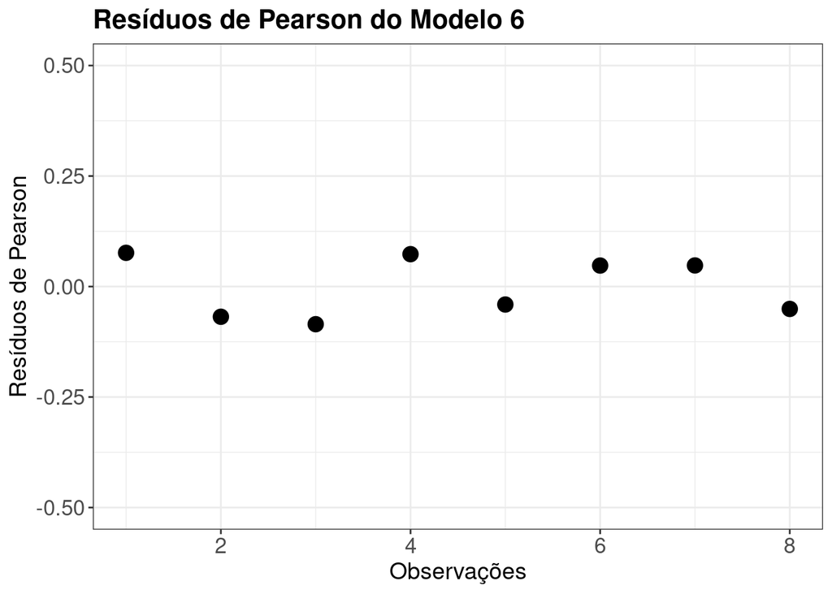

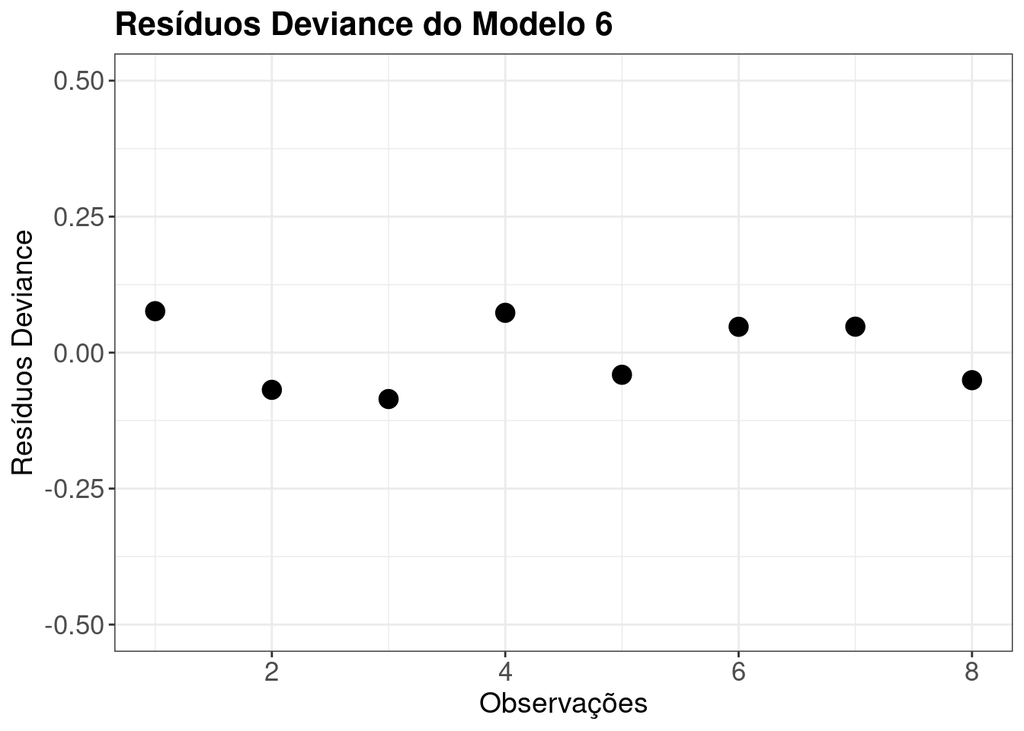